# BI 410 Problem Set 4

Credits: Mindy Tran Professor: Dr. Lauren Hallett DUE: 11/18/2021 *Please submit as an html file and show all your work (i.e., do NOT put echo = FALSE in your chunk)*

## Creating workflows with the Portal Project

For each of the following prompts, please:

1. Identify the information needed
2. Identify the datasets that have this information
3. Write the in-English workflow needed to go from raw data to question
4. Write the R code using tidyverse syntax to go from raw data to question. Note: it’s good practice to comment your code with hashtags as you go. **I expect you to do this.**

**Please turn in your assignment as a rendered .html file that *shows your work*. i.e., leave echo = TRUE (the default)**

### 1) How many plots of each type are there?

1. Information needed: plot types, occurences of each plot type recorded
2. Datasets needed: plots, surveys
3. English workflow:
- Use the plot_id from “plots” dataset to match plot_id in “surveys” to a plot_type
- Count how many rows are in each plot type and select unique values
4. R workflow:

```r
# Use the plot_id from "plots" dataset to match plot_id in "surveys" to a plot_type
tog <- right_join(plots, surveys)
numTypes <- tog %>%
  group_by(plot_type) %>%
  add_count() %>% # Count how many rows are in each plot type and select unique values
  select(plot_type, n) %>%
  unique()

numTypes
```

```
## # A tibble: 5 x 2
## # Groups:   plot_type [5]
##   plot_type                     n
##   <chr>                     <int>
## 1 Spectab exclosure          3931
## 2 Control                   15660
## 3 Long-term Krat Exclosure   5259
## 4 Rodent Exclosure           4744
## 5 Short-term Krat Exclosure  5955
```

### 2) What is the average weight across rodent species?

Hint: Averaging within a species first might account for bias from population size

1. Information needed: taxa to find rodents, species, weight, calcSE, mean
2. Datasets needed: species, surveys
3. English workflow:
- Join species and surveys datasets
- find the average weight in each species
- isolate rodents
- find mean and SE of weight in Rodents
4. R workflow:

```r
# Join species and surveys datasets
tog <- right_join(species, surveys)
rodentWeight <- tog %>%
  filter(!is.na(weight)) %>%
  group_by(species)  %>%
  mutate(meanweight = mean(weight, na.rm = TRUE), seWeight = calcSE(weight)) %>% # find the average weight in each species
  select(taxa, species, meanweight, seWeight) %>%
  unique() %>%
  filter(taxa == "Rodent") %>% # isolate rodents
  unique()

print(rodentWeight, n = 22)
```

```
## # A tibble: 22 x 4
## # Groups:   species [22]
##    taxa   species      meanweight seWeight
##    <chr>  <chr>             <dbl>    <dbl>
##  1 Rodent taylori            8.6    0.310
##  2 Rodent merriami          43.2    0.0674
##  3 Rodent ordii             48.9    0.147
##  4 Rodent spectabilis      120.     0.473
##  5 Rodent albigula         159.     1.30
##  6 Rodent leucogaster       31.6    0.220
##  7 Rodent torridus          24.2    0.0966
##  8 Rodent sp.               19.5    1.11
##  9 Rodent baileyi           31.7    0.131
## 10 Rodent eremicus          21.6    0.117
## 11 Rodent flavus             7.92   0.0416
## 12 Rodent hispidus          65.6    2.12
## 13 Rodent intermedius       19.2    0.526
## 14 Rodent leucopus          19.1    0.690
## 15 Rodent maniculatus       21.4    0.163
## 16 Rodent penicillatus      17.2    0.0667
## 17 Rodent fulvescens        13.4    0.255
## 18 Rodent megalotis         10.6    0.0440
## 19 Rodent montanus          10.2    0.648
## 20 Rodent fulviventer       58.9    4.34
## 21 Rodent ochrognathus      55.4    3.43
## 22 Rodent spilosoma         93.5   36.5
```

### 3) What percentage of the rodents captured in the Portal project control plots were in the genus Dipodomys?

Hint: you might want to join two datasets into an intermediate dataframe to join to again

1. Information needed: taxa for rodents, genus for Dipodomys, plot_type for control
2. Datasets needed: surveys, species, and plots
3. English workflow:
- join all datasets
- count number of rodents in control plots
- count number of Dipodomys in control plots
- calculate the percentage of Dipodomys
- hold unique values
4. R workflow:

```r
tog <- right_join(species, surveys)
```

```r
tog <- left_join(tog, plots) # join all datasets
percDipo <- tog %>%
  filter(plot_type == "Control", taxa == "Rodent") %>%
  add_count() %>% rename("numcontrol" = n) %>% # count number of rodents in control plots
  filter(genus == "Dipodomys") %>%
  group_by(genus) %>%
  add_count() %>% rename("numDip" = n) %>% # count number of Dipodomys in control plots
  select(genus, taxa, plot_type, numcontrol, numDip) %>%
  mutate(percentDipo = numDip/numcontrol * 100) %>% # calculate the percentage of Dipodomys
  unique()%>% # hold unique values
  select(genus, taxa, plot_type, percentDipo)

percDipo
```

```
## # A tibble: 1 x 4
## # Groups:   genus [1]
##   genus     taxa   plot_type percentDipo
##   <chr>     <chr>  <chr>           <dbl>
## 1 Dipodomys Rodent Control          63.7
```

### 4) What are the minimum, maximum and average weight for each species of Rodent?

1. Information needed: species, taxa, weight
2. Datasets needed: survey, species
3. English workflow:
- join survey and species datasets
- isolate rodents
- group by species
- find min, mean, max weight for each species
4. R workflow:

```r
tog <- right_join(species, surveys) # join all datasets
```

```r
boxplotRodents <- tog %>%
  filter(!is.na(weight)) %>%
  filter(taxa == "Rodent") %>% # isolate rodents
  group_by(species)  %>% # group by species
  # find min, mean, max weight for each species
  mutate(minWeight = min(weight), maxWeight = max(weight), meanWeight = mean(weight)) %>%
  select(species, taxa, minWeight, maxWeight, meanWeight) %>% unique()

print(boxplotRodents, n = 22)
```

```
## # A tibble: 22 x 5
## # Groups:   species [22]
##    species      taxa   minWeight maxWeight meanWeight
##    <chr>        <chr>      <dbl>     <dbl>      <dbl>
##  1 taylori      Rodent         6        18       8.6
##  2 merriami     Rodent        10        66      43.2
##  3 ordii        Rodent        12        76      48.9
##  4 spectabilis  Rodent        12       190     120.
##  5 albigula     Rodent        30       280     159.
##  6 leucogaster  Rodent        10        56      31.6
##  7 torridus     Rodent         5        46      24.2
##  8 sp.          Rodent        11        24      19.5
##  9 baileyi      Rodent        12        55      31.7
## 10 eremicus     Rodent         8        40      21.6
## 11 flavus       Rodent         4        25       7.92
## 12 hispidus     Rodent        16       140      65.6
## 13 intermedius  Rodent        17        21      19.2
## 14 leucopus     Rodent         8        27      19.1
## 15 maniculatus  Rodent         7        49      21.4
## 16 penicillatus Rodent         4        74      17.2
## 17 fulvescens   Rodent         9        20      13.4
## 18 megalotis    Rodent         4        29      10.6
## 19 montanus     Rodent         8        13      10.2
## 20 fulviventer  Rodent        24       199      58.9
## 21 ochrognathus Rodent        15       105      55.4
## 22 spilosoma    Rodent        57       130      93.5
```

### 5) Is there a correlation between the average annual weights of the three Dipodomys species? Explore this visually.

Hint: You may need to “untidy” the data

1. Information needed: weights, species_id, year, species
2. Datasets needed: surveys, species
3. English workflow:
- join datasets
- change columns to date y-m-d
- isolate the Dipodomys
- group by year/date and species
- mutate annual weights and SE
- unique values
- graph
4. R workflow:

```r
tog <- right_join(species, surveys) # join all datasets
```

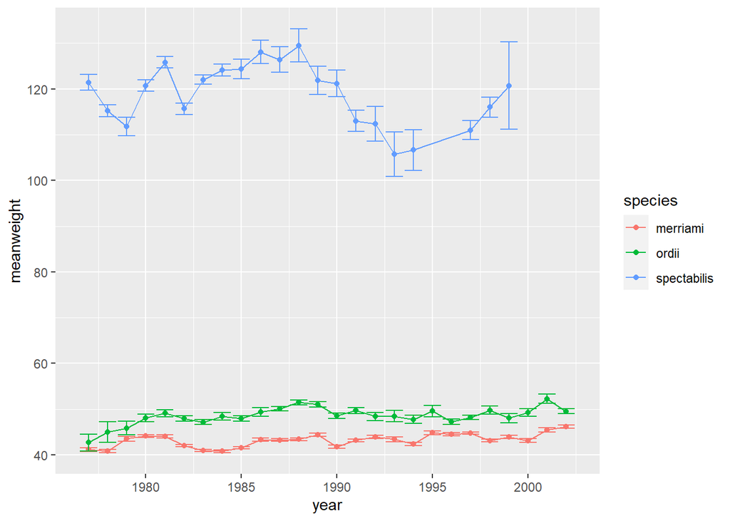

```r
tog$Date<-as.Date(with(tog,paste(year,month,day,sep="-")),"%Y-%m-%d")

yearWeight <- tog %>%
  filter(genus == "Dipodomys") %>%
  select(genus, species, year, Date, weight) %>%
  group_by(species, year) %>%
  mutate(meanweight = mean(weight, na.rm = TRUE), seweight = calcSE(weight)) %>%
  select(genus, species, year, meanweight, seweight) %>%
  filter(species != "sp.") %>%
  unique()

ggplot(yearWeight, aes(x = year, y= meanweight, color = species)) + geom_point() + geom_line() +
  geom_errorbar(aes(ymin = meanweight - seweight, ymax = meanweight + seweight))
```

### 6) Using data from the Portal Project, please recreate the following figure. Please match the aesthetics of the figure as closely as possible (e.g., labels, colors, font and line size, axis-ticks, etc).

- isolate control plots
- isolate Dipodomys spectabilis
- group by year/date and species
- mutate annual weights and SE
- unique values
- graph, color = sex

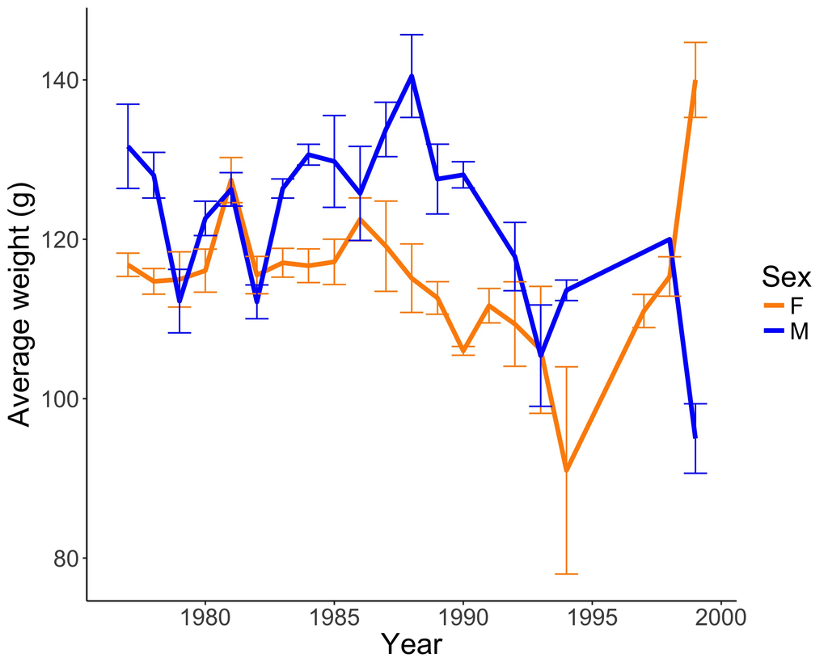

Figure 1. Average weight (+/- SE) of *Dipodomys spectabilis* over time by sex in the control plots of the Portal Project.

```r
tog <- right_join(species, surveys)
```

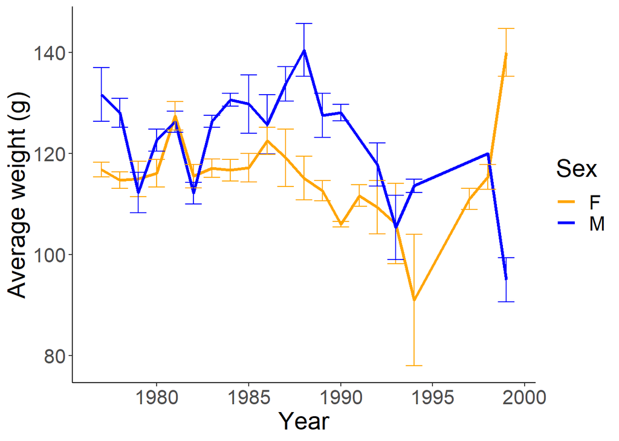

```r
tog <- left_join(tog, plots) # join all datasets
figdat <- tog %>%
  filter(plot_type == "Control", genus == "Dipodomys", species == "spectabilis", !is.na(weight), !is.na(sex)) %>%
  group_by(sex, year) %>%
  mutate(meanweight = mean(weight, na.rm = TRUE), seweight = calcSE(weight)) %>%
  select(genus, species, sex, year, meanweight, seweight) %>%  unique()


ggplot(figdat, aes(x = year, y= meanweight, color = sex)) + geom_point(size = .1) + geom_line(size = 1.2) +
  scale_color_manual(values = c("orange", "blue")) +
  geom_errorbar(aes(ymin = meanweight - seweight, ymax = meanweight + seweight)) +
  labs(x = "Year", y = "Average weight (g)", color = "Sex") +
  theme_classic() +
  scale_y_continuous(breaks = seq(80, 140, by = 20), labels = seq(80, 140, by = 20)) +
   theme(text = element_text(size = 20))
```